# 차기작 기획을 위한 데이터 분석

지역별, 시기별로 선호장르, 출고량 점유율 등을 통해 가장 인기가 있을 것 같은 장르와 주목해야할 지역을 선정한다.

# 지역별 선호 장르 변화

```python
part1 = (recent['Year'] >= 1994) & (recent['Year'] < 2005)
part2 = (recent['Year'] >= 2005) & (recent['Year'] < 2011)
part3 = (recent['Year'] >= 2011) & (recent['Year'] < 2017)
```

```python
pd.concat([NA, EU, Other, JP], axis=1)
```

|  | NA_Genre_Part3 | EU_Genre_Part3 | Other_Genre_Part3 | JP_Genre_Part1 | JP_Genre_Part2 | JP_Genre_Part3 |
| --- | --- | --- | --- | --- | --- | --- |
| 0 | Shooter | Action | Action | Role-Playing | Platform | Simulation |
| 1 | Shooter | Sports | Shooter | Role-Playing | Role-Playing | Role-Playing |
| 2 | Action | Shooter | Shooter | Role-Playing | Simulation | Role-Playing |
| 3 | Shooter | Shooter | Action | Role-Playing | Puzzle | Role-Playing |
| 4 | Shooter | Action | Action | Role-Playing | Role-Playing | Role-Playing |

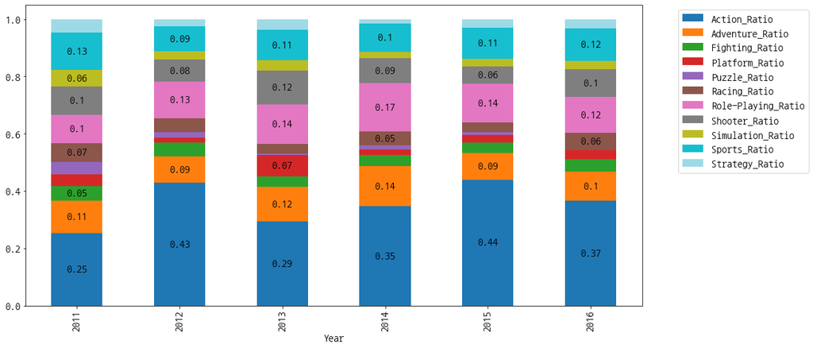

```python
ratio_col = tmp.columns[-11:]

ax = tmp[ratio_col].plot.bar(stacked=True, cmap='tab20', figsize=(16, 8), legend=False)
ax.legend(bbox_to_anchor=(1.05, 1), loc='upper left')
for rect in ax.patches:
    height = rect.get_height()
    width = rect.get_width()
    x = rect.get_x()
    y = rect.get_y()
    label_text = round(height, 2)
    label_x = x + width / 2
    label_y = y + height / 2
    if height > 0.05:
        ax.text(label_x, label_y, label_text, ha='center', va='center')
```

미국, 유럽, 기타 지역은 선호 장르 변화가 비슷한 양상을 보인다.  
하지만 일본은 선호장르의 변화가 거의 없다고 할 수 있다.

# 시기별 게임 트렌드

### 1. 시기별 게임 출고량 지역 비중

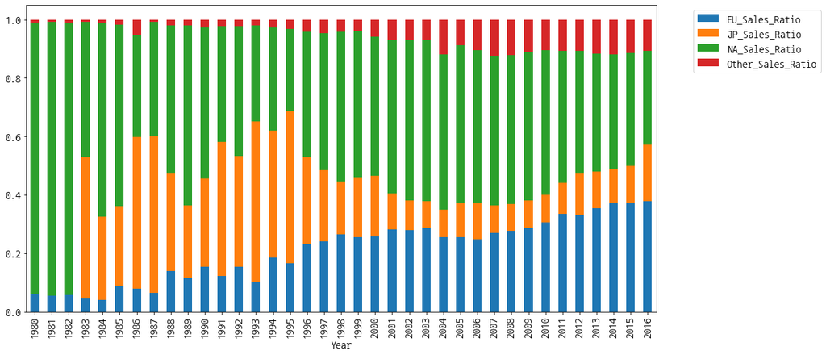

```python
df_ratio.plot.bar(stacked=True, figsize=(16, 8))
plt.legend(bbox_to_anchor=(1.05, 1), loc='upper left')
```

90년대 일본비중이 높았으나 줄어들고 유럽비중 증가하고 있다.  
유럽이 미국도 추월하는 추세로 보인다.

### 2. 대세 플랫폼의 변화

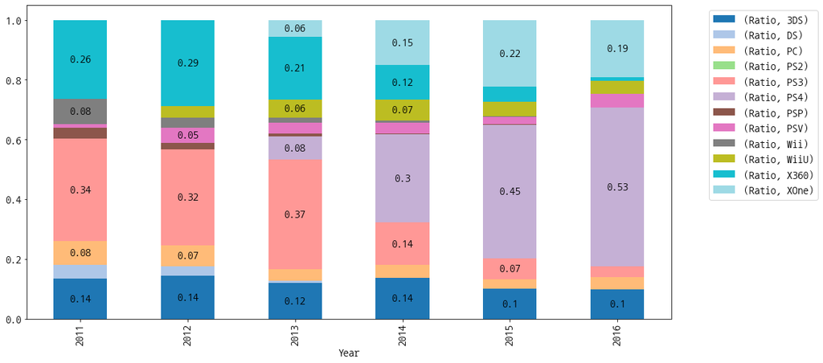

```python
ax = part3_platform_ratio.plot.bar(stacked=True, figsize=(16, 8), cmap='tab20', legend=False)
ax.legend(bbox_to_anchor=(1.05, 1), loc='upper left')
for rect in ax.patches:
    height = rect.get_height()
    width = rect.get_width()
    x = rect.get_x()
    y = rect.get_y()
    label_text = round(height, 2)
    label_x = x + width / 2
    label_y = y + height / 2
    if height > 0.05:
        ax.text(label_x, label_y, label_text, ha='center', va='center')
```

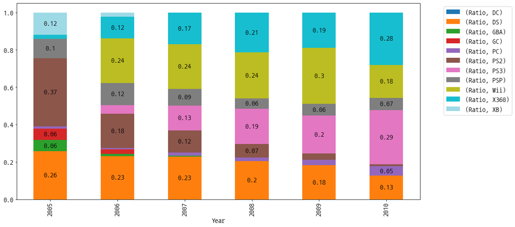

```python
ax = part2_platform_ratio.plot.bar(stacked=True, figsize=(16, 8), cmap='tab20', legend=False)
ax.legend(bbox_to_anchor=(1.05, 1), loc='upper left')
for rect in ax.patches:
    height = rect.get_height()
    width = rect.get_width()
    x = rect.get_x()
    y = rect.get_y()
    label_text = round(height, 2)
    label_x = x + width / 2
    label_y = y + height / 2
    if height > 0.05:
        ax.text(label_x, label_y, label_text, ha='center', va='center')
```

PS -> PS2 -> PS3 & XBOX 360 -> PS4 콘솔 세대교체를 볼 수 있다.  
아무리 점유율이 높았더라도 새로운 콘솔 기기가 출시되면 대세는 옮겨가게 된다.

2000년대 닌텐도 전성기로 플레이스테이션과 Xbox로 양분된 콘솔 시장에 새로운 축으로 부상했으나 그 이후 힘을 쓰지 못했다.